# Focos de queimadas nas microrregiões do Matopiba, Brasil

Gisele Milare

2022-02-21

A ocorrência de queimadas e incêndios florestais causam impactos ambientais, sociais e econômicos. Saber onde as queimadas ocorrem é útil para criar planos de ação de prevenção de controle, principalmente em regiões onde ela é frequente.

Nos últimos anos, a ocorrência de queimadas tem sido frequente na região do Matopiba, sendo o local de maior área queimada no bioma Cerrado.

Nesse contexto, o objetivo é apresentar uma análise da ocorrência de focos de queimadas, no período de 2011 a 2021, nas microrregiões do Matopiba e identificar:

1. Em quais microrregiões ocorreram o maior número de focos de queimadas;
2. Em quais microrregiões ocorreram maior número de focos de queimadas por km²;
3. Quais meses do ano há maior ocorrência de focos de queimadas.

# 1 Região do Matopiba

O Matopiba é uma região formada pelo Estado do Tocantins e parte dos Estados do Maranhão, Piauí e Bahia. A região é considerada uma fronteira agrícola e seu nome é um acrônimo formado com as iniciais dos nomes dos estados que a compõe.

O Matopiba é uma região delimitada através de um estudo da Embrapa (Miranda, Magalhães, and Carvalho 2014), onde é disponibilizada uma lista de municípios e microrregiões. Essa delimitação em microrregiões e municípios permitir subrecortes territoriais de forma a ser operacional para seu uso. A delimitação teve por base principalmente as áreas de Cerrado e a dimensão socioeconômica, principalmente as relacionadas a agropecuária. A definição da área do Matopiba corresponde aos limites de 31 microrregiões (Figura 1.1) e de 337 municípios.

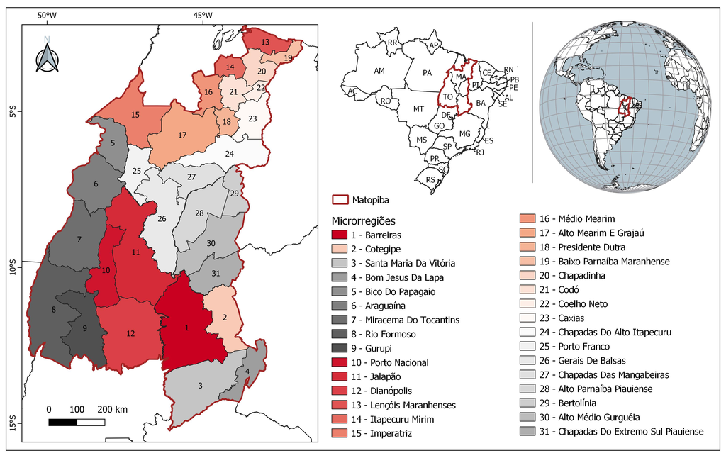

Figure 1.1: Mapa de localização do Matopiba e das microrregiões. Fonte dos dados limites estaduais e das microrregiões: IBGE (2019).

De modo a manter a delimitação atualizada da área da região do Matopiba, foi utilizada a base atualizada (ano 2020) de feições das microrregiões do IBGE (2019).

# 2 Ocorrência de focos de queimada nas microrregiões do Matopiba

Foram utilizados dados de focos de queimadas que são indicativos para fogo ativo. Os dados foram obtidos na plataforma do [Programa Queimadas/INPE](https://queimadas.dgi.inpe.br/) para o período de 2011 a 2021. Foram considerados somente os focos obtidos do satelite de referência, indicado para análises temporais.

A tabela abaixo mostra o número de ocorrência de focos de queimadas nas microrregiões do Matopiba. As microrregiões Alto Mearim e Grajaú (MA), Jalapão (TO) e Rio Formoso (TO) apresentação maior número de ocorrência de focos de queimadas no período de 2011 a 2021, com 39.799, 37.259 e 32.586 focos, respectivamente.

|  | Microrregião | 2011 | 2012 | 2013 | 2014 | 2015 | 2016 | 2017 | 2018 | 2019 | 2020 | 2021 | Total |
| --- | --- | --- | --- | --- | --- | --- | --- | --- | --- | --- | --- | --- | --- |
| 1 | Alto Mearim e Grajaú | 2387 | 7008 | 2543 | 4800 | 4975 | 3406 | 5808 | 2145 | 3064 | 1948 | 1715 | 39799 |
| 2 | Alto Médio Gurguéia | 1709 | 2604 | 975 | 1012 | 1860 | 992 | 718 | 1019 | 1141 | 873 | 1391 | 14294 |
| 3 | Alto Parnaíba Piauiense | 2199 | 3613 | 1372 | 2320 | 1912 | 1367 | 1611 | 1287 | 1776 | 1405 | 1754 | 20616 |
| 4 | Araguaína | 553 | 782 | 469 | 732 | 707 | 609 | 1166 | 333 | 354 | 836 | 262 | 6803 |
| 5 | Baixo Parnaíba Maranhense | 451 | 719 | 681 | 566 | 701 | 612 | 616 | 407 | 482 | 434 | 457 | 6126 |
| 6 | Barreiras | 2862 | 4077 | 1015 | 1323 | 2498 | 1031 | 1367 | 785 | 1472 | 1263 | 2576 | 20269 |
| 7 | Bertolínia | 1141 | 1115 | 558 | 1220 | 892 | 349 | 894 | 1184 | 1140 | 763 | 1108 | 10364 |
| 8 | Bico do Papagaio | 679 | 647 | 510 | 818 | 941 | 513 | 1018 | 397 | 488 | 561 | 462 | 7034 |
| 9 | Bom Jesus da Lapa | 769 | 734 | 396 | 281 | 666 | 247 | 133 | 167 | 337 | 332 | 491 | 4553 |
| 10 | Caxias | 628 | 2748 | 716 | 1274 | 1962 | 2121 | 1635 | 769 | 996 | 1142 | 1073 | 15064 |

[output cut: 21 more lines]

Na Figura 2.1 é apresentado os mapas de ocorrência de focos de queimadas por microrregião expressa pelo número de focos por km². As micrroregiões com mais focos de queimadas por km² foram as microrregiões Alto Mearim e Grajaú com 0,19 focos/km² em 2012, Chapadas do Extremo Sul Piauiense com 0,19 focos/km² em 2015 e Chapadas do Alto Itapecuru com 0,18 focos/km² em 2012.

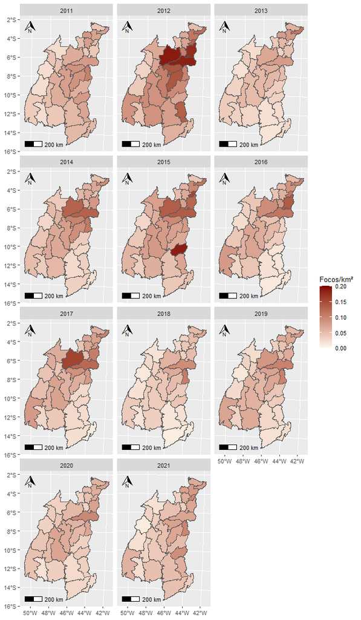

Figure 2.1: Mapa anual de ocorrência de focos queimadas por km² nas microrregiões do Matopiba.

Na Figura 2.2 é apresentado os gráficos para cada microrregião com a ocorrência número de focos de queimadas por km², com dados mensais do período analisado (2011 a 2021). É possivel observar que há uma sazonalidade dessa ocorrência, que é apresentada na Figura 2.3 através de gráficos polares para cada microrregião. Os meses de maior ocorrência são agosto, setembro e outubro.

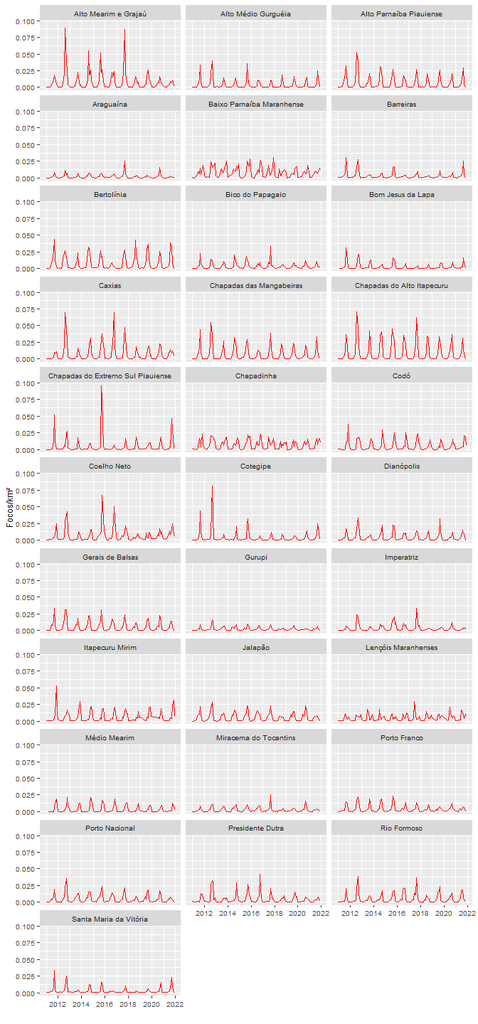

Figure 2.2: Gráfico de número de focos de queimadas mensais por km², no período de 2011 a 2021, por microrregião.

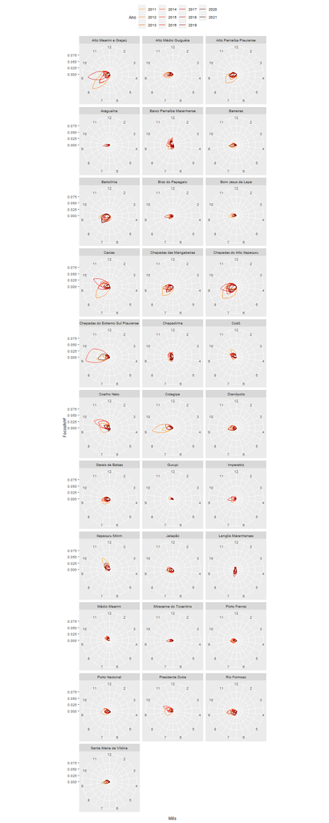

Figure 2.3: Gráfico polar de número de focos de queimadas por km² mensais por microrregião no período de 2011 a 2021.

O relatório foi feito utilizando o software R (R Core Team 2021) com os seguintes pacotes: dplyr (Wickham, François, et al. 2021), DT (Xie, Cheng, and Tan 2021), geobr (Pereira and Goncalves 2021), ggplot2 (Wickham, Chang, et al. 2021), ggspatial (Dunnington 2021), knitr (Xie 2021), lubridate (Spinu, Grolemund, and Wickham 2021), purrr (Henry and Wickham 2020), readr (Wickham, Hester, and Bryan 2022), scales (Wickham and Seidel 2020), sf (Pebesma 2021), tidyr (Wickham 2021). Foi utilizado o template de tema *tactile* do pacote prettydoc (Qiu 2021).

# Referências

Dunnington, Dewey. 2021. *Ggspatial: Spatial Data Framework for Ggplot2*. https://CRAN.R-project.org/package=ggspatial.

Henry, Lionel, and Hadley Wickham. 2020. *Purrr: Functional Programming Tools*. https://CRAN.R-project.org/package=purrr.

IBGE. 2019. “Geociências.” Instituto Brasileiro de Geografia e Estatística (IBGE). https://www.ibge.gov.br/geociencias/downloads-geociencias.html.

Miranda, Evaristo Eduardo de, Lucı́ola Alves Magalhães, and Carlos Alberto de Carvalho. 2014. “Proposta de Delimitação Territorial Do MATOPIBA.” *Embrapa Territorial-Outras Publicações técnicas (INFOTECA-E)*.

Pebesma, Edzer. 2021. *Sf: Simple Features for r*. https://CRAN.R-project.org/package=sf.

Pereira, Rafael H. M., and Caio Nogueira Goncalves. 2021. *Geobr: Download Official Spatial Data Sets of Brazil*. https://github.com/ipeaGIT/geobr.

Qiu, Yixuan. 2021. *Prettydoc: Creating Pretty Documents from r Markdown*. https://github.com/yixuan/prettydoc.

R Core Team. 2021. *R: A Language and Environment for Statistical Computing*. Vienna, Austria: R Foundation for Statistical Computing. https://www.R-project.org/.

Spinu, Vitalie, Garrett Grolemund, and Hadley Wickham. 2021. *Lubridate: Make Dealing with Dates a Little Easier*. https://CRAN.R-project.org/package=lubridate.

Wickham, Hadley. 2021. *Tidyr: Tidy Messy Data*. https://CRAN.R-project.org/package=tidyr.

Wickham, Hadley, Winston Chang, Lionel Henry, Thomas Lin Pedersen, Kohske Takahashi, Claus Wilke, Kara Woo, Hiroaki Yutani, and Dewey Dunnington. 2021. *Ggplot2: Create Elegant Data Visualisations Using the Grammar of Graphics*. https://CRAN.R-project.org/package=ggplot2.

Wickham, Hadley, Romain François, Lionel Henry, and Kirill Müller. 2021. *Dplyr: A Grammar of Data Manipulation*. https://CRAN.R-project.org/package=dplyr.

Wickham, Hadley, Jim Hester, and Jennifer Bryan. 2022. *Readr: Read Rectangular Text Data*. https://CRAN.R-project.org/package=readr.

Wickham, Hadley, and Dana Seidel. 2020. *Scales: Scale Functions for Visualization*. https://CRAN.R-project.org/package=scales.

Xie, Yihui. 2021. *Knitr: A General-Purpose Package for Dynamic Report Generation in r*. https://yihui.org/knitr/.

Xie, Yihui, Joe Cheng, and Xianying Tan. 2021. *DT: A Wrapper of the JavaScript Library DataTables*. https://github.com/rstudio/DT.